# Session 20 Script: ggplot

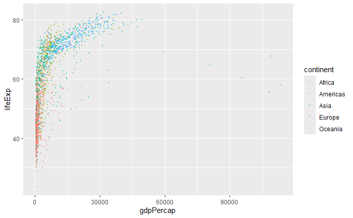

```r
ggplot(gapminder, aes(x = gdpPercap, y = lifeExp)) +
  geom_point(alpha = 0.5, size = 0.5, aes(color = continent))
```

We are not limited to mapping only one additional variable, we can map many, here we alos map the population size of each country in each year to the size of the data point. In this way we can convey a lot of information rapidly. THough the visualization below is quite jumbled.

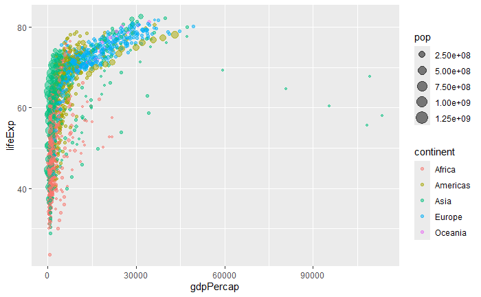

```r
ggplot(gapminder, aes(x = gdpPercap, y = lifeExp, color = continent, size = pop)) +
  geom_point(alpha = 0.5)
```

We of course are not only limited to point geometries. There are many, many types. Lines are shown below.

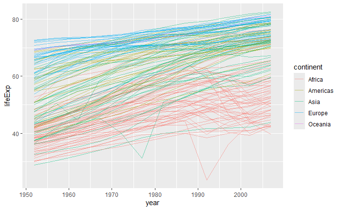

```r
ggplot(gapminder, aes(x = year, y = lifeExp, group = country, color = continent)) +
  geom_line(alpha = 0.5)
```

We can also do a boxplot easily, which makes good sense for a continuous dependant variable and a categorical independent variable. Some ggplot geomteries, use color for the outline and fill for the main color of a plot.

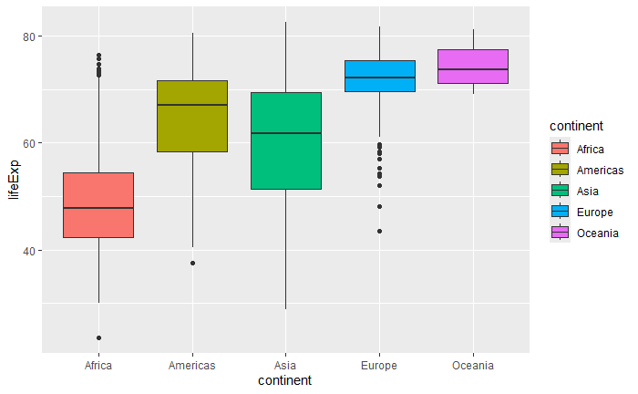

```r
ggplot(gapminder, aes(x = continent, y = lifeExp, fill = continent)) +
  geom_boxplot()
```

We can make histograms, with one continuous variable quite easily, and bar charts with the combination of geom_bar( stat = “identity”) if one has the actual values included in the Y variable.

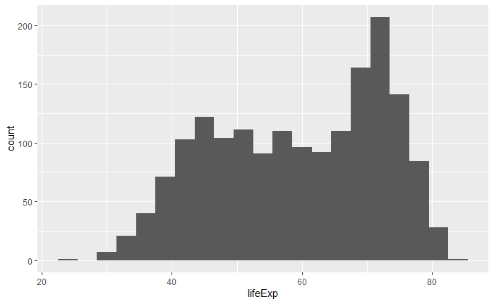

```r
ggplot(gapminder, aes(x = lifeExp)) +
  geom_histogram(binwidth = 3)
```

Ggplot allows a simple implementation of smooth functions which can include loess, gam, and most regression models using a geom_smooth() argument.

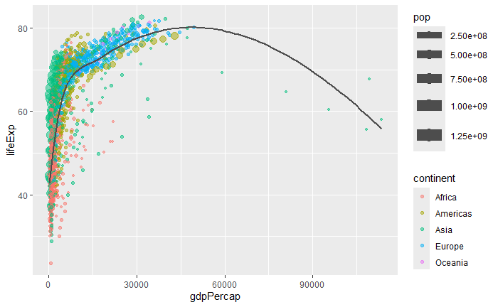

```r
ggplot(gapminder, aes(x = gdpPercap, y = lifeExp, size = pop)) +
  geom_point(aes(color = continent), alpha = 0.5) +
  geom_smooth(se = FALSE, method = "loess", color = "grey30")
```

it also works well as an output of a pipe command because the data argument is first.

[figure not shown]

We can change aspects about the axes such as putting them on log scales.

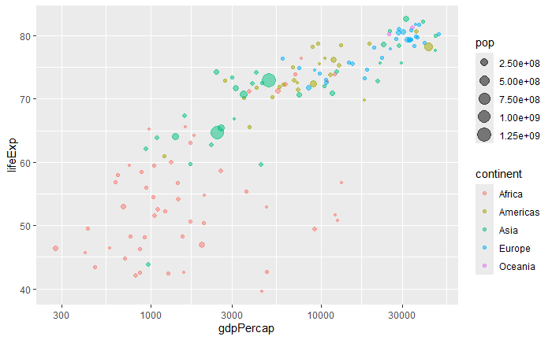

```r
gapminder %>% filter(year == 2007) %>%
ggplot(aes(x = gdpPercap, y = lifeExp, color = continent, size = pop)) +
  geom_point(alpha = 0.5) +
  scale_x_log10()
```

and give them specific markers.

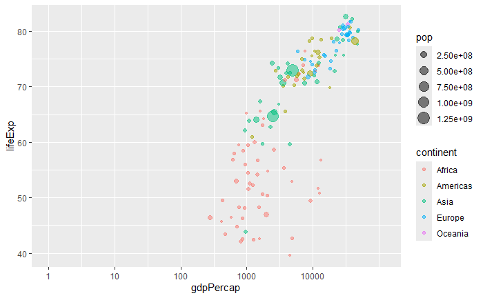

```r
gapminder %>% filter(year == 2007) %>%
ggplot(aes(x = gdpPercap, y = lifeExp, color = continent, size = pop)) +
  geom_point(alpha = 0.5) +
  # clean the x-axis breaks
  scale_x_log10(breaks = c(1, 10, 100, 1000, 10000),
                limits = c(1, 120000))
```

or fix their labels so that they are appropriately descriptive rather than simply using the variable names.

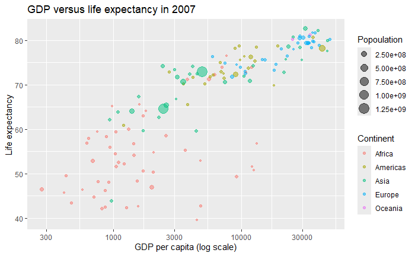

```r
gapminder %>% filter(year == 2007) %>%
ggplot(aes(x = gdpPercap, y = lifeExp, color = continent, size = pop)) +
  # add scatter points
  geom_point(alpha = 0.5) +
  # log-scale the x-axis
  scale_x_log10() +
  # change labels
  labs(title = "GDP versus life expectancy in 2007",
       x = "GDP per capita (log scale)",
       y = "Life expectancy",
       size = "Popoulation",
       color = "Continent")
```

We can also provide similar fixes for the legend

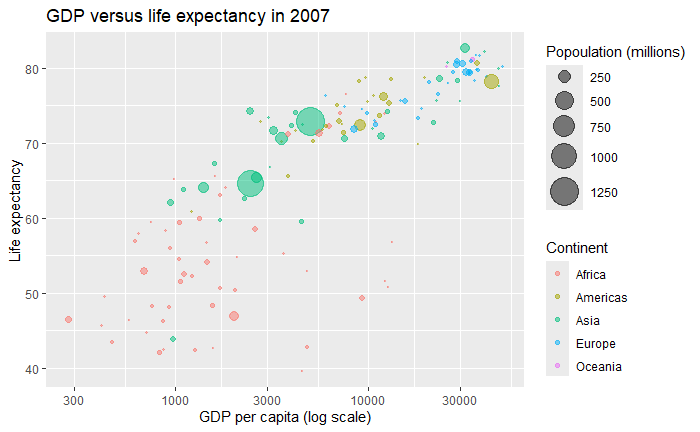

```r
gapminder %>% filter(year == 2007) %>%
ggplot(aes(x = gdpPercap, y = lifeExp, color = continent, size = pop)) +
  # add scatter points
  geom_point(alpha = 0.5) +
  # log-scale the x-axis
  scale_x_log10() +
  # change labels
  labs(title = "GDP versus life expectancy in 2007",
       x = "GDP per capita (log scale)",
       y = "Life expectancy",
       size = "Popoulation (millions)",
       color = "Continent") +
  # change the size scale
  scale_size(range = c(0.1, 10),
             breaks = 1000000 * c(250, 500, 750, 1000, 1250),
             labels = c("250", "500", "750", "1000", "1250"))
```

faceting and facet_wrap() and facet_grid() provide formula based approaches to creating multiple panels in the same chart. Here we use a single variable to create these.

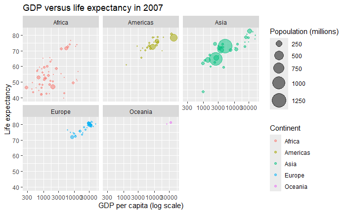

```r
gapminder %>% filter(year == 2007) %>%
ggplot(aes(x = gdpPercap, y = lifeExp, color = continent, size = pop)) +
  # add scatter points
  geom_point(alpha = 0.5) +
  # log-scale the x-axis
  scale_x_log10() +
  # change labels
  labs(title = "GDP versus life expectancy in 2007",
       x = "GDP per capita (log scale)",
       y = "Life expectancy",
       size = "Popoulation (millions)",
       color = "Continent") +
  # change the size scale
  scale_size(range = c(0.1, 10),
             breaks = 1000000 * c(250, 500, 750, 1000, 1250),
             labels = c("250", "500", "750", "1000", "1250")) +
  # add faceting
  facet_wrap(~continent)
```

There are also many themes which provide simple paths to changing alot of the basic look of the charts.

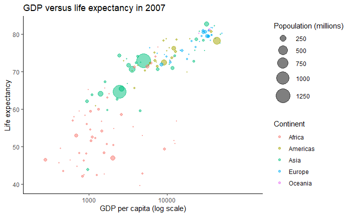

```r
gapminder %>% filter(year == 2007) %>%
ggplot(aes(x = gdpPercap, y = lifeExp, color = continent, size = pop)) +
  # add scatter points
  geom_point(alpha = 0.5) +
  # clean the axes names and breaks
  scale_x_log10(breaks = c(1000, 10000),
                limits = c(200, 120000)) +
  # change labels
  labs(title = "GDP versus life expectancy in 2007",
       x = "GDP per capita (log scale)",
       y = "Life expectancy",
       size = "Popoulation (millions)",
       color = "Continent") +
  # change the size scale
  scale_size(range = c(0.1, 10),
             breaks = 1000000 * c(250, 500, 750, 1000, 1250),
             labels = c("250", "500", "750", "1000", "1250")) +
  # add a nicer theme
  theme_classic()
```

We can move the legend around.

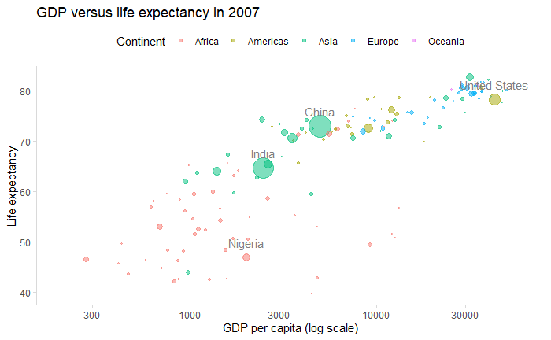

```r
gapminder_2007 <- gapminder %>% filter(year == 2007)
gapminder %>% filter(year == 2007) %>%
ggplot() +
  # add scatter points
  geom_point(aes(x = gdpPercap, y = lifeExp, color = continent, size = pop),
             alpha = 0.5) +
  # add some text annotations for the very large countries
  geom_text(aes(x = gdpPercap, y = lifeExp + 3, label = country),
            color = "grey50",
            data = filter(gapminder_2007, pop > 1000000000 | country %in% c("Nigeria", "United States"))) +
  # clean the axes names and breaks
  scale_x_log10(limits = c(200, 60000)) +
  # change labels
  labs(title = "GDP versus life expectancy in 2007",
       x = "GDP per capita (log scale)",
       y = "Life expectancy",
       size = "Popoulation",
       color = "Continent") +
  # change the size scale
  scale_size(range = c(0.1, 10),
             # remove size legend
             guide = "none") +
  # add a nicer theme
  theme_classic() +
  # place legend at top and grey axis lines
  theme(legend.position = "top",
        axis.line = element_line(color = "grey85"),
        axis.ticks = element_line(color = "grey85"))
```

and we can save ggplots as objects in the normal way and call them later, we can also save them as image files easily using ggsave().

```r
p <- gapminder %>% filter(year == 2007) %>% ggplot() +
  # add scatter points
  geom_point(aes(x = gdpPercap, y = lifeExp, color = continent, size = pop),
             alpha = 0.5) +
  # add some text annotations for the very large countries
  geom_text(aes(x = gdpPercap, y = lifeExp + 3, label = country),
            color = "grey50",
            data = filter(gapminder_2007, pop > 1000000000 | country %in% c("Nigeria", "United States"))) +
  # clean the axes names and breaks
  scale_x_log10(limits = c(200, 60000)) +
  # change labels
  labs(title = "GDP versus life expectancy in 2007",
       x = "GDP per capita (log scale)",
       y = "Life expectancy",
       size = "Popoulation",
       color = "Continent") +
  # change the size scale
  scale_size(range = c(0.1, 10),
             # remove size legend
             guide = "none") +
  # add a nicer theme
  theme_classic() +
  # place legend at top and grey axis lines
  theme(legend.position = "top",
        axis.line = element_line(color = "grey85"),
        axis.ticks = element_line(color = "grey85"))

# save the plot
ggsave("beautiful_plot.png", p, dpi = 300, width = 6, height = 4)
```

[output not shown]

ggmap is a related package that integrates some basic mapping and interaction with the goole maps (and other) APIs with ggplot. We’ll show below some basic uses of this as examples. Note that currently google requires one to register using a credit card for the use of the google maps API in this way, and that one can be charged by google if use exceeds some threseholds.

Instructions on how to do this are found here: [google API and ggmap](https://www.littlemissdata.com/blog/maps)

First, just getting a map. The get_map() function from ggmap can pull maps from google as well as some other sites. Note that we can actually use geocodes for this, or more or less anythig that goes into the google maps search field and finds a map directly.

[figure not shown]

```r
locus <- "Basilica di San Marco, Venezia, Italy"

myMap <- get_map(location=locus, zoom= 18, source="google",
                 maptype="roadmap", crop=TRUE)
ggmap(myMap)
```

We can get all the kinds of visualizations that google maps already has.

[figure not shown]

```r
myMap <- get_map(location=locus, zoom= 18,
                 source="google", maptype="satellite", crop=TRUE)
ggmap(myMap)
```

At all the zoom levels.

[figure not shown]

```r
myMap <- get_map(location=locus, zoom= 19,
                 source="google", maptype="hybrid", crop=TRUE)
ggmap(myMap)
```

We can also get stamen/stadia maps which have some nice visualizations.

```r
#myMap <- get_map(location=locus, zoom= 15,
#                 source="stadia", maptype="stamen_watercolor", crop=TRUE)
#ggmap(myMap)
```

Another example.

```r
myMap <- get_map(location=locus, zoom= 15,
                 source="stadia", maptype="stamen_toner", crop=TRUE)
```

```
ℹ © Stadia Maps © Stamen Design © OpenMapTiles © OpenStreetMap contributors.
```

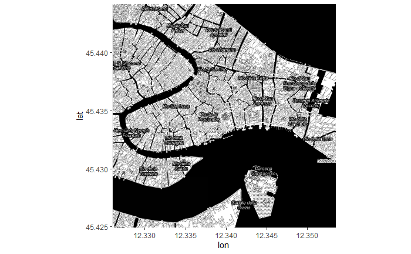

```r
ggmap(myMap)
```

The geocode() function performs geocoding (identifying latitude and longitude (or other specific geographic information from strings such as addresses or place names)). Then we can overlay ggplot geometries to enhance the google map backgrounds.

```r
addresses <- c("3627 1st St New Orleans LA 70125", "1428 Chartres St New Orleans LA 70116")

data_df <- data.frame(address = addresses)
data_df <- cbind(data_df, geocode(addresses, source = "google"))
locus <- "New Orleans"
myMap <- get_map(location=locus, zoom= 14,
                 source="stadia", maptype = "outdoors", crop=TRUE)
```

```
ℹ © Stadia Maps © Stamen Design © OpenMapTiles © OpenStreetMap contributors.
```

[figure not shown]

```r
ggmap(myMap) + geom_point(data = data_df, aes( x = lon, y = lat))
```

Here is an example using Seattle crime data that shows how these visualizations can nicely integrate map capabilities with standard plotting approaches. note the specification of color below uses hex color approach, there are many ways to describe color [Color Hex](https://www.w3schools.com/colors/colors_hexadecimal.asp) is one. red, green, blue (RGB) is another and there are many more.

```r
#incidents <- read.csv('https://raw.githubusercontent.com/lgellis/MiscTutorial/master/ggmap#/i2Sample.csv', stringsAsFactors = FALSE)

#write_csv(incidents, path = "C:/Users/jyukich/Documents/sphu4160/fall_2019/class_lib_R/incidents.csv" )

incidents <- read_csv("C:/Users/jyukich/Documents/sphu4160/fall_2019/class_lib_R/incidents.csv")
dim(incidents)
```

```
[1] 50000    20
```

```r
head(incidents)
```

| X | CAD.CDW.ID | CAD.Event.Number | General.Offense.Number | Event.Clearance.Code | Event.Clearance.Description | Event.Clearance.SubGroup | Event.Clearance.Group | Event.Clearance.Date | Hundred.Block.Location | District.Sector | Zone.Beat | Census.Tract | Longitude | Latitude | Incident.Location | Initial.Type.Description | Initial.Type.Subgroup | Initial.Type.Group | At.Scene.Time |
| --- | --- | --- | --- | --- | --- | --- | --- | --- | --- | --- | --- | --- | --- | --- | --- | --- | --- | --- | --- |
| 450024 | 813558 | 12000168676 | 2012168676 | 064 | SHOPLIFT | THEFT | SHOPLIFTING | 05/31/2012 06:00:00 PM | 39XX BLOCK OF S OTHELLO ST | S | S1 | 11000.1011 | -122.2823 | 47.53704 | (47.537044021, -122.282344886) | NA | NA | NA | NA |
| 1028516 | 1002946 | 12000438147 | 2012438147 | 100 | FRAUD (INCLUDING IDENTITY THEFT) | FRAUD CALLS | FRAUD CALLS | 12/24/2012 11:14:00 AM | 27XX BLOCK OF ALKI AVE SW | W | W1 | 9701.2000 | -122.4100 | 47.57932 | (47.579317217, -122.409989598) | TRU - FORGERY/CHKS/BUNCO/SCAMS/ID THEFT | FRAUD CALLS | FRAUD CALLS | 12/24/2012 10:33:00 AM |
| 1319344 | 1036985 | 15000080173 | 201580173 | 161 | TRESPASS | TRESPASS | TRESPASS | 03/11/2015 12:45:00 PM | 6XX BLOCK OF NW MARKET ST | B | B2 | 4800.4000 | -122.3646 | 47.66865 | (47.668651602, -122.364558421) | BURG - RES (INCL UNOCC STRUCTURES ON PROP) | BURGLARY | RESIDENTIAL BURGLARIES | NA |
| 1334148 | 1053917 | 15000105067 | 2015105067 | 100 | FRAUD (INCLUDING IDENTITY THEFT) | FRAUD CALLS | FRAUD CALLS | 03/31/2015 04:56:00 PM | 77XX BLOCK OF RAINIER AV S | S | S2 | 11102.4008 | -122.2700 | 47.53314 | (47.533143434, -122.269986901) | FRAUD - FORGERY,BUNCO, SCAMS, ID THEFT, ETC | FRAUD CALLS | FRAUD CALLS | NA |
| 32080 | 48491 | 10000294206 | 2010294206 | 281 | SUSPICIOUS VEHICLE | SUSPICIOUS CIRCUMSTANCES | SUSPICIOUS CIRCUMSTANCES | 08/23/2010 01:06:00 AM | 23XX BLOCK OF LAKE PARK DR S | R | R1 | 9500.3001 | -122.2882 | 47.58018 | (47.580182752, -122.288159086) | NA | NA | NA | NA |
| 326478 | 681155 | 11000387576 | 2011387576 | 250 | MISCHIEF, NUISANCE COMPLAINTS | NUISANCE, MISCHIEF COMPLAINTS | NUISANCE, MISCHIEF | 12/01/2011 11:36:00 PM | 3 AV / PIKE ST | K | K1 | 8100.2010 | -122.3378 | 47.60975 | (47.609748462, -122.337793005) | NA | NA | NA | NA |

```r
col1 <- "#CC0000"

#add year to the incidents data frame
incidents$ymd <- mdy_hms(incidents$Event.Clearance.Date)
incidents$year <- year(incidents$ymd)

#Create a more manageable data frame with only 2017 and 2018 data
i2 <- incidents %>%
  filter(year>=2017 & year<=2018)

#Only include complete cases
i2[complete.cases(i2), ]
```

[output not shown]

[output cut: 990 more lines]

[figure not shown]

```r
p <- get_map(location =  c(lon = -122.335167, lat = 47.608013),
                    zoom = 14, scale = 2,
                    maptype ='satellite',
                    color = 'color')
p <- ggmap(p)
p + geom_point(aes(x = Longitude, y = Latitude), alpha=0.3, size = 0.5, colour = col1, data = i2) + theme(legend.position="none")
```